# Groundfish Module Summary

Ben Galuardi

2022-06-24

### 0.0.1 Background

Discards of groundfish species are used for several purposes throughout the year. Quota Monitoring requires these on a weekly basis. Discard rates for sector trips are shared with Sector managers. End of year ACL accounting also requires discard estimates from all trips.

This means a full accounting of groundfish discards occurs in several steps.

### 0.0.2 Steps for Groundfish Trips

1. Pull all merged trips from `CAMS_OBS_CATCH`. Here, it is a good idea to pull only a few years and not the whole table, which is ~12 years of data
2. Separate Groundfish trips from non-groundfish trips (Use CAMS `GF` column)
3. Set stratification variables for groundfish trips

```r
# FULL Stratification variables

stratvars = c( 'SPECIES_ESTIMATION_REGION'
                            # , 'GEARCODE'  # this is the SECGEAR_MAPPED variable
              , 'CAMS_GEAR_GROUP'
              , 'MESHGROUP'
              , 'SECTID'
              , 'EM'  # previously was four columns of EFP information..
              , "REDFISH_EXEMPTION"
              , "SNE_SMALLMESH_EXEMPTION"
              , "XLRG_GILLNET_EXEMPTION"
              )
```

```
- SPECIES_ESTIMATION_REGION is taken from CAMS support table `MAPS.CAMS_STATAREA_STOCK`
- CAMS_GEAR_GROUP is derived from a support table (`MAPS.CAMS_GEARCODE_STRATA`)
- MESHGROUP is hardcoded for all trips according to decisions made by the mesh subgroup (see summary when available)
- SECTID comes from a CAMS matching table (`MAPS.MATCH_MULT_SECTID`)
- EFP and Exemptions are built in to `CAMS_LANDINGS`, the precurdor for `CAMS_OBS_CATCH`
```

4. Perform *first pass* of `discaRd`
   - there are two sub-passes for year t and year t-1
5. Perform *second pass* of `discaRd` with discard rates rolled up for all Sectors
   - Common Pool is distinguished from the rest of Sectors
   - Simplified stratification is used:

```r
# Assumed Stratification variables

stratvars = c('SPECIES_ESTIMATION_REGION'
              , 'CAMS_GEAR_GROUP'
              , 'MESHGROUP'
                            , 'SECTOR_TYPE'
              )
```

6. The discaRd functions allow for an assumed rate to be calculated. This assumed rate is relative to the stratification used in the functions. Here, we utilize this feature to generate a broad stock rate. the stratification here is simply `SPECIES_ESTIMATION_REGION`
7. For each *pass*, a transition rate is calculated between year t and year t-1. This rate determines how much, if any, information is used from previous years.
8. The two *passes* are joined in a hierarchical manner. Rates and `DISCARD_SOURCE` for groundfish estimates from groundfish trips are as follows (in parentheses):
- 1. in season rate; >= 5 trips in Full Stratification
- 20. Transition in season rate; < 5 trips in Full Stratification, year t, AND >= 5 trips in year t-1
- 1. Assumed rate. This is the *second pass* rate that rolls up all Sectors. Common Pool trips are separated in this strata.
- 2. Broad stock rate is used when other criteria are not met.
- (EM) Electronic monitoring (EM) video based estimate. If the trip is reviewed and passed; and there was no human observer on board.
- (VTR) VTR (self-reported) discard estimate on an EM trip that was reviewed and failed; and there was no human observer on board.
- (DELTA) Delta model estimate of VTR discard on an EM trip that was reviewed and failed; and there was no human observer on board.
- 15. Observed values used from observed trips; discard rate is NOT USED.

groundfish estimates from non-groundfish trips are as follows:

- 1. in season rate; >= 5 trips in Full Stratification
- 20. Transition in season rate; < 5 trips in Full Stratification, year t, AND >= 5 trips in year t-1
- (GM) Assignment is from the second pass (e.g. Stock/Gear/Meshgroup). This is the rate when there were <5 trips in season and <5 in previous season at the full stratification level.
- 7. Assignment is from the *second pass* (e.g. Stock/Gear). This rate uses two years of information (e.g. current year and previous year).
- 14. No coverage in focal season and previous season; discard rate is not possible to estimate.
- 15. Observed values used from observed rate trips; discard rate is NOT USED.
9. CV calculations are available for (I), (T), (GM), (G) and (A). (O) rates are not used and final discard values are not estimated.
10. Discard pounds per trip are calculated according to

```r
    mutate(coalesce(DISC_MORT_RATIO, 1)) %>%
    mutate(DISCARD = case_when(!is.na(LINK1) ~ DISC_MORT_RATIO*OBS_DISCARD
                                                         , is.na(LINK1) ~ DISC_MORT_RATIO*COAL_RATE*LIVE_POUNDS)

            # COAL_RATE is the final discard rate used. It is 'coalesced' from the (I), (A) and (B) rates
```

By assigning `SPECIES_ESTIMATION_REGION` as a stratification variable, the computation time is reduced. Each subtrip may only occur in a single statistical area so it should never cross stock boundaries.

Once the full table (CAMS_OBS_CATCH) is loaded, each species takes ~12 seconds to process on the server. non-groundfish trips take ~1-2 minutes as there are many more trips and table rows.

Output tables are produced for each species and fishing year. These are then combined into a single `View` on `MAPS` and `CAMS_GARFO`

```sql
    MAPS.CAMS_DISCARD_ALL_YEARS
    CAMS_GARFO.CAMS_DISCARD_ALL_YEARS

    /* Get groundfish discards from groundfish trips for FY 2019
       FY 2021 currently has EM values
    */

        select *
    from MAPS.CAMS_DISCARD_ALL_YEARS
     where GF = 1
    AND FED_OR_STATE = 'FED'
    AND FY = 2019
    AND SPECIES_ITIS in ('172877' ,
    '164712' ,
    '164732' ,
    '166774',
    '171341',
    '172873',
    '172909',
    '164727',
    '172933',
    '172746',
    '172905',
    '164744',
    '630979')
```

### 0.0.3 Diagnostic Plots/Tables

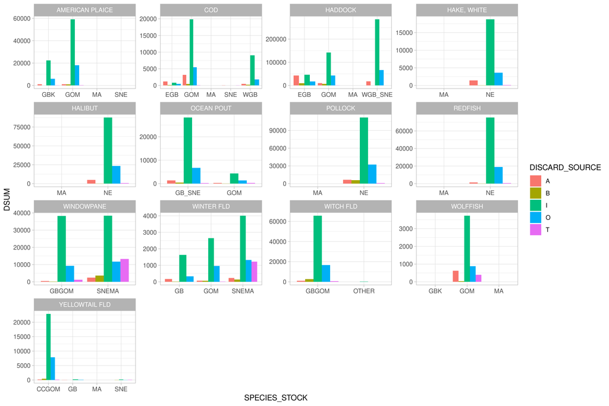

Discard Estimate by Stock, Species, Discard Source

|  | COMMON_NAME | SPECIES_ESTIMATION_REGION | nvtr | KALL | DISCARD |
| --- | --- | --- | --- | --- | --- |
| 1 | AMERICAN PLAICE | GBK | 3162 | 32463426 | 29692 |
| 2 | AMERICAN PLAICE | GOM | 5158 | 40520484 | 79495 |
| 3 | AMERICAN PLAICE | MA | 369 | 1851171 | 0 |
| 4 | AMERICAN PLAICE | SNE | 1003 | 7031300 | 25 |
| 5 | COD | EGB | 178 | 2578415 | 2588 |
| 6 | COD | GOM | 5158 | 40520484 | 29021 |
| 7 | COD | MA | 369 | 1851171 | 35 |
| 8 | COD | SNE | 1003 | 7031300 | 186 |
| 9 | COD | WGB | 2984 | 29885011 | 11536 |
| 10 | HADDOCK | EGB | 178 | 2578415 | 115865 |

[output cut: 27 more lines]

|  | COMMON_NAME | DMIS_STOCK_ID | CAMS_DISCARD | DMIS_DISCARD | DMIS_CAMS_DIFF | DMIS_CAMS_DIFF_PERC |
| --- | --- | --- | --- | --- | --- | --- |
| 1 | AMERICAN PLAICE | PLAGMMA | 109212 | 109023 | -189 | -0.00173357915302276 |
| 2 | COD | CODGBE | 2588 | 6383 | 3795 | 0.594548018173273 |
| 3 | COD | CODGBW | 11757 | 11052 | -705 | -0.0637893593919653 |
| 4 | COD | CODGMSS | 29021 | 29973 | 952 | 0.0317619190604878 |
| 5 | HADDOCK | HADGBE | 115865 | 107176 | -8689 | -0.0810722549824588 |
| 6 | HADDOCK | HADGBW | 370025 | 384367 | 14342 | 0.0373132969271556 |
| 7 | HADDOCK | HADGM | 201960 | 202985 | 1025 | 0.00504963420942434 |
| 8 | HAKE, WHITE | HKWGMMA | 23946 | 21184 | -2762 | -0.130381419939577 |
| 9 | HALIBUT | HALGMMA | 116855 | 103889 | -12966 | -0.124806283629643 |
| 10 | OCEAN POUT | OPTGMMA | 43338 | 41017 | -2321 | -0.0565862934880659 |

[output cut: 12 more lines]

| STOCK_ID_DMIS | STOCK_ID_CAMS | KALL_DMIS | KALL_CAMS | SPECIES_ITIS | KALL_DIFF | KALL_DIFF_PERC |
| --- | --- | --- | --- | --- | --- | --- |
| CODGBW | WGB | 28329577 | 28295172 | 164712 | 34405 | 0.001 |
| CODGBW | SNE | 5253674 | 5006981 | 164712 | 246693 | 0.047 |
| CODGMSS | GOM | 38457440 | 38497766 | 164712 | -40326 | -0.001 |
| CODGBW | MA | 1325672 | 1455596 | 164712 | -129924 | -0.098 |
| CODGBE | EGB | 2608786 | 2604937 | 164712 | 3849 | 0.001 |
| HKWGMMA | NE | 74649478 | 74404856 | 164732 | 244622 | 0.003 |
| HKWGMMA | MA | 1325672 | 1455596 | 164732 | -129924 | -0.098 |
| REDGMGBSS | NE | 74649478 | 74404856 | 166774 | 244622 | 0.003 |
| REDGMGBSS | MA | 1325672 | 1455596 | 166774 | -129924 | -0.098 |
| PLAGMMA | SNE | 5253674 | 5006981 | 172877 | 246693 | 0.047 |

[output cut: 27 more lines]

### 0.0.4 Steps for estimation of groundfish discard on non-Groundfish Trips

1. same as above
2. same as above
3. Set stratification variables

```r
# Full (First Pass) Stratification variables

stratvars = c('SPECIES_ESTIMATION_REGION'
              ,'CAMS_GEAR_GROUP'
                            , 'MESHGROUP'
                          , 'TRIPCATEGORY'
                          , 'ACCESSAREA')
```

```
- SPECIES_ESTIMATION_REGION is taken from CAMS support table `MAPS.CAMS_STATAREA_STOCK`
- CAMS_GEAR_GROUP is derived from a support table (`MAPS.CAMS_GEARCODE_STRATA`)
- MESHGROUP is hardcoded for all trips according to decisions made by the mesh subgroup (see summary when available)
- TRIPCATEGORY is specific to scallop trips and indicates Limited Access or General Category Fleets
- ACCESS AREA is specific to scallop trips and indicates Scallop Access Area
```

4. Run first pass of `discaRd` for full stratification
   - there are sub-passes for year t and year t-1
5. Run a second pass using a coarsened stratification : ‘SPECIES_ESTIMATION_REGION’, ‘CAMS_GEAR_GROUP’ and ‘MESHGROUP’.

```r
# Second Pass Stratification variables

stratvars = c('SPECIES_ESTIMATION_REGION'
              , 'CAMS_GEAR_GROUP',
              ,'MESHGROUP')
```

```r
# Third PAss Stratification variables

stratvars = c('SPECIES_ESTIMATION_REGION'
              , 'CAMS_GEAR_GROUP',
              ,'MESHGROUP')
```

7. Trips/Gear strata that are unobserved after these steps are not assigned rates as no observer coverage exists for these gear types (e.g. Menhaden purse seine)
8. Rates and `DISCARD_SOURCE` (in parentheses) are assigned for each trip according to:
- 1. in season rate; >= 5 trips in Full Stratification
- 20. Transition in season rate; < 5 trips in Full Stratification, year t, AND >= 5 trips in year t-1
- (GM) Assignment is from the second pass (e.g. Stock/Gear/Meshgroup). This is the rate when there were <5 trips in season and <5 in previous season at the full stratification level.
- 7. Assignment is from the second pass (e.g. Stock/Gear).
- 14. No coverage in focal season and previous season; discard rate is not possible to estimate.
- 15. Observed values used from observed rate trips; discard rate is NOT USED.
9. CV calculations are available for (I), (T), (G) and (GM).
10. Discard pounds per trip are calculated according to

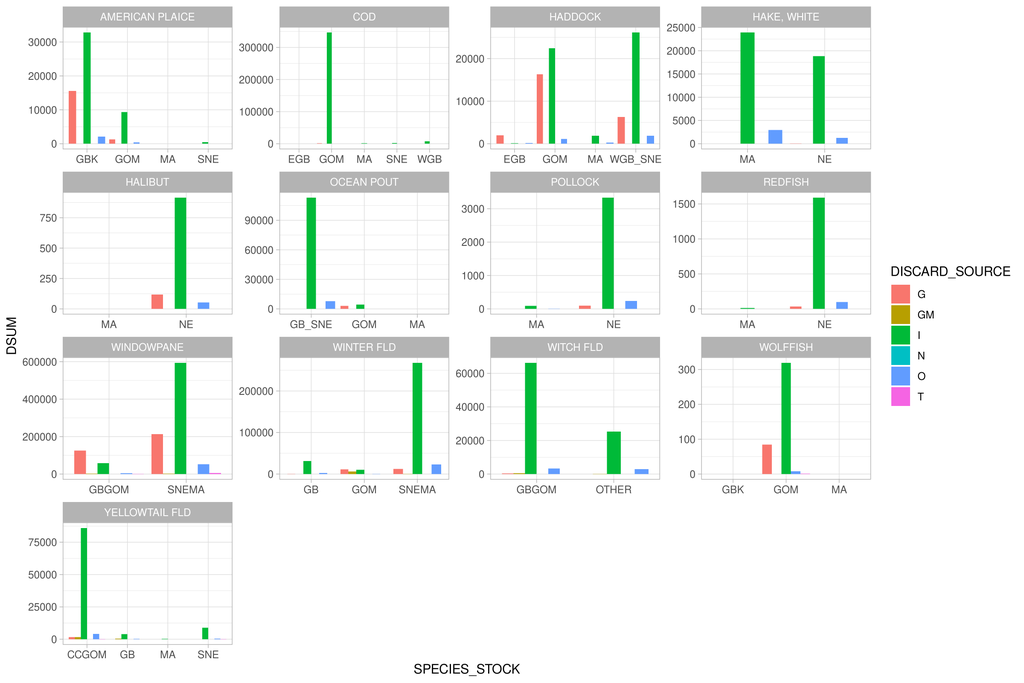

Non-groudfish trips: Discard Estimate by Stock, Species, Discard Source

|  | COMMON_NAME | SPECIES_STOCK | FED_OR_STATE | DISCARD | KALL | N_VTR |
| --- | --- | --- | --- | --- | --- | --- |
| 1 | HADDOCK | EGB | FED | 2286.17194634942 | 46387839 | 529 |
| 2 | HALIBUT | NE | FED | 1087.32831529835 | 663196866 | 47303 |
| 3 | OCEAN POUT | MA | FED | 12.1826825639554 | 675233738 | 8847 |
| 4 | WINDOWPANE | GBGOM | FED | 191925.131781276 | 359720425 | 33077 |
| 5 | WOLFFISH | GOM | FED | 413.341810944194 | 256807821 | 32143 |
| 6 | YELLOWTAIL FLD | SNE | FED | 9629.69180342538 | 444902516 | 25564 |
| 7 | COD | GOM | FED | 348534.12625447 | 149066491 | 27977 |
| 8 | COD | EGB | FED | 157.959315621564 | 46387839 | 529 |
| 9 | OCEAN POUT | GOM | FED | 7701.2129458303 | 149066491 | 27977 |
| 10 | WINDOWPANE | SNEMA | FED | 867792.23653661 | 1268734282 | 39068 |

[output cut: 28 more lines]

```r
    mutate(DISC_MORT_RATIO = coalesce(DISC_MORT_RATIO, 1)) %>%
    mutate(DISCARD = case_when(!is.na(LINK1) ~ DISC_MORT_RATIO*OBS_DISCARD
                                                         , is.na(LINK1) ~ DISC_MORT_RATIO*COAL_RATE*LIVE_POUNDS)

    # COAL_RATE is the final discard rate used. It is 'coalesced' from the (I), (GM) and (G) rates
```